# Reproduction Number Code

Created by Nel Jason Haw

Last updated December 14, 2020

This page gives you a step-by-step instruction guide on how to calculate reproduction number using surveillance data from an infectious disease outbreak.

Before starting in this page, please visit the [**README file**](https://neljasonhaw.github.io/ReproductionNumber). There are instructions for beginners on how to install R and RStudio, getting familiar with R, an introduction to tidy data, and what R packages to install (installing packages only needs to be done once).

# 1 Getting Ready

## 1.1 Downloading dummy data (if you wanna follow along completely)

The rest of this guide uses dummy data. If you want to recreate all of the analyses using the dummy data, visit the [**Github repository here**](https://github.com/neljasonhaw/ReproductionNumber). Click on the green button `Code` then click `Download ZIP`. Unzip and look for the file name `linelist.csv`.

There’s also an R script file called `ReproductionNumber.R`. That R script file contains all the codes in this guide. You may open that as you follow along. All of the other files are not relevant for the guide or are output files that will be generated as part of the analysis.

While the files may usually be found in your Downloads folder, move it to a new folder anywhere else in your computer (say, your Documents folder) and give it a name. This new folder will serve as our working directory, so remember where it is.

## 1.2 Creating an RStudio project

1. Open RStudio. On the menu bar, select `File` > `New Project...`
2. The `New Project Wizard` dialog box opens. select `Existing Directory`.
3. Under `Project working directory`, select `Browse...` and locate the folder of the working directory.
4. Select `Create Project.` At this point, you have created a new project file (.Rproj) as well as set the working directory.
5. Create a new R script file using the keyboard shortcut `Ctrl-Shift-N` or going to `File` > `New File` > `R Script` or clicking on the New File button on the topmost left corner right below the menu bar then clicking `R Script`. The left side of the environment should split into two - with the script file found on the upper left side. The script file is similar to a do file for those who are familiar with Stata. Ideally, we should be saving all our code in a script file in case we need to redo or repeat analyses so that all we have to do is to run the script rather than coding everything from scratch again.
6. Save the script file every now and then. Give it a name. In the repository, this is named `ReproductionNumber.R`. Open that script file if you just want to run the code.

## 1.3 Loading packages

We will need to load the relevant R packages first. Make sure that the packages are installed prior to loading them. On the script file you just created, run the following codes:

```r
library(tidyverse)      # General data analysis package
library(janitor)        # General data cleaning package
library(R0)             # Reproduction number
library(incidence)      # Generating incidence tables
library(writexl)        # Export to Excel spreadsheet
```

You can opt to skip the characters beginning from the `#` sign - Anything written with the `#` sign are comments. I would recommend you keeping them so that you won’t forget what each line of code means.

Now, highlight the five lines of code on your script file, then click the `Run` button on the upper right portion of the `Script` window. Alternatively, you can also use the keyboard shortcut `Ctrl-Enter` to run the code. The codes should appear on the `Console` window on the lower left. Moving forward, whenever we want to run a chunk of code one at a time, we highlight the code we want to run, then we either click the `Run` button or enter `Ctrl-Enter`. Stata users will find this workflow very familiar, as this is the same that is done with do files.

# 2 Data Preparation

## 2.1 Tidy data: linelist

Before starting to code, make sure that the tidy data version of your surveillance data is already available on your working directory. For those who want to follow along with dummy data, we have already done this. For those who want to use your own line list of cases, make sure you have done it at this point and rename the file as `linelist.csv` so that you do not have to change anything in the codes below.

**IMPORTANT: when you are exporting your own surveillance data to comma-separated values (CSV) format from Excel, make sure to choose the file type option “CSV (Macintosh).” The other CSV file types do not render properly in R.**

Raw data cleaning is highly dependent on the raw data you have, so if you are not yet familiar with data cleaning using R, clean the data elsewhere first. This guide will not teach you how to clean the data, although this arguably takes majority of one’s time when doing data analysis.

The line list, at the minimum, should contain the following columns:

- **`ID`**: Unique, static ID number that identifies each case
- **`DateOnset`**: Date of symptom onset as reported by the case - often, symptom onset data is not complete and is imputed in many ways, such as using the date of testing (**`DateTested`**) and date of reporting (**`DateReported`**) instead
  - The imputation methods are highly dependent on the decisions made by the surveillance team. This guide will not make any prescriptions on what the appropriate method is.
  - Make sure to include all other variables that may be needed to impute the `DateOnset` variable, or if there is already a variable available with the imputed values, just use that one instead as `DateOnset`
- Any other variables that may be used to stratify the data: If you want to generate reproduction numbers per municipality (**`Municipality`**), for example, then retrieve the municipality variable as well.

In line with tidy data principles, make sure that any categorical variable has clean values (no typographical errors, no different versions of the same category), and that all date variables have a uniform format. **I recommend using the date format “YYYY-MM-DD”.**

For those using their own data, I would recommend to rename your columns to the column names above so that you do not have to change anything in the codes below.

First, let’s take a look at the dummy data quickly. Run the following lines of code and a table showing the first six rows should appear on the `Console`:

```r
linelist <- read.csv("linelist.csv")        # Importing the linelist.csv file
head(linelist)                              # Displaying the first six rows of linelist
```

```
##   ID   Municipality  DateOnset DateTested DateReported
## 1  1 Municipality C 2020-03-07 2020-03-16   2020-03-25
## 2  2 Municipality D 2020-03-05 2020-03-19   2020-03-31
## 3  3 Municipality C 2020-03-15 2020-03-20   2020-03-31
## 4  4 Municipality E 2020-03-15 2020-03-18   2020-04-02
## 5  5 Municipality C 2020-03-21 2020-03-23   2020-04-03
## 6  6 Municipality C 2020-03-24 2020-03-27   2020-04-03
```

Let’s try to create an imputed version of the `DateOnset` variable called `DateOnset_imputed`. In this hypothetical case, let’s have a simple rule: If `DateOnset` is missing, then use `DateTested` minus 2 days; if both `DateOnset` and `DateTested`are missing, then use `DateReport` minus 4 days.

Run the following code. Note that R does not mind when you break commands into multiple lines using `Enter`. In this case, given that the last line of code is too long, we decided to split it into more visually intuitive chunks. R will read the last four lines are one command. The indentation does not matter to R as well; it is more for us to see and understand the code more clearly.

```r
# Telling R that the date variables are dates with format YYYY-MM-DD
linelist$DateOnset <- as.Date(linelist$DateOnset, "%Y-%m-%d")
linelist$DateTested <- as.Date(linelist$DateTested, "%Y-%m-%d")
linelist$DateReported <- as.Date(linelist$DateReported, "%Y-%m-%d")
# Imputation algorithm - hypothetical, replace based on your context
linelist <- linelist %>%
  mutate(DateOnset_imputed = case_when(is.na(DateOnset) & !is.na(DateTested) ~ DateTested - 2,
                                       is.na(DateOnset) & is.na(DateTested) ~ DateReported - 4,
                                       TRUE ~ DateOnset))
```

Now let’s run some checks to make sure the code ran correctly. Given that we imputed the `DateOnset` variable, one check we can do is to count how many missing values `DateOnset_imputed` variable has - the correct answer should be zero.

```r
# Counts how many missing values are in DateOnset_imputed
sum(is.na(linelist$DateOnset_imputed))
```

```
## [1] 0
```

## 2.2 Generating incidence table

Now that we have our imputed dates of symptom onset, we are ready to generate incidence tables. An incidence table is just a frequency table with each row representing a calendar date, together with the count of cases for that date.

**IMPORTANT: The incidence table must have each date PER DAY as a row within the time period. This means that dates with zero cases should still appear as one row each. If you chose to generate an incidence table elsewhere, say, using the PivotTable command in Excel, or even through the `table` command in R, the reproduction number calculation will not work.**

- **`DateOnset_imputed`**: This is the variable with imputed dates of symptom onset calculated earlier.
- **`Count`**: The number of new cases on that particular date. This should be a discrete variable, meaning there should only be positive integers, since we are counting people.

Run the following lines of code to generate the incidence table, called `incidencetable`.

```r
# Generate incidence table as incidence object (incidence)
incidence <- incidence(linelist$DateOnset_imputed)
# Generate incidence table as frequency table
incidencetable <- data.frame(incidence$dates, incidence$counts)
# Rename columns
colnames(incidencetable) <- c("DateOnset_imputed", "Count")
# Displaying the first six rows of incidence table
head(incidencetable)
```

```
##   DateOnset_imputed Count
## 1        2020-03-05     1
## 2        2020-03-06     1
## 3        2020-03-07     1
## 4        2020-03-08     3
## 5        2020-03-09     3
## 6        2020-03-10     0
```

```r
# Export incidence table to Excel spreadsheet if you need it elsewhere (optional)
write_xlsx(incidencetable, "incidencetable.xlsx")
```

Notice how Row 6, March 10, 2020, has zero cases and is tallied as such. If you had used other commands to generate the incidence table and this date did not show up, then you did not generate the incidence table correctly.

# 3 Estimating Reproduction Number

## 3.1 Declaring serial interval distribution

A serial interval distribution must be declared beforehand. You may estimate serial interval either by:

- Retrieving the distribution and parameters from literature - usually you would find these values in modelling studies. Take note of the assumptions and context in which these parameters were originally used before applying them to your own analysis.
- Identifying a subset of your linelist with known infector-infectee pairs that have complete data on dates of symptom onset. Calculate the serial interval between these pairs and model the most appropriate distribution and calculate relevant parameters.

This guide will not teach you how to model a serial interval distribution.

For this guide, we will use a hypothetical example from one of my research studies estimating epidemiological parameters at the start of the COVID-19 pandemic in the Philippines ([doi: 10.1017/S0950268820002137](https://www.cambridge.org/core/journals/epidemiology-and-infection/article/epidemiological-profile-and-transmission-dynamics-of-covid19-in-the-philippines/FF71A51A25F004AC59885AFA4C88C48B)). In that study, we used a serial interval for COVID-19 with a Weibull distribution, with mean 7.0 days and standard deviation 5.5 days.

Run the following code to store the serial interval distribution in a list called `mGT`

```r
mGT <- generation.time("weibull", c(7.0, 5.5), nrow(linelist))
```

## 3.2 Choosing an appropriate time period for the analysis

When estimating time-varying reproduction number $R_t$, it is best for us to first identify an appropriate time period for the analysis. This guide will not teach you how to identify that appropriate time period, but keep in mind three things:

- At the beginning stages of an infectious disease outbreak, cases may not be growing exponentially yet, especially if the cases are occurring far apart from one another for it to be considered epidemiologically-linked. Therefore, we usually choose a start period generally around the time when cases start to exponentially increase.
- We usually do not interpret time-varying reproduction numbers too close to the present, given that there are significant surveillance lags between time from symptom onset to surveillance reporting. That lag period is to be determined based on the surveillance team’s understanding of this lag. Every health system is unique in this regard and careful considerations must be made because reproduction numbers close to the present are expected to decrease during the present because more cases are yet to be reported, and should not be interpreted as a true decrease in cases.
- Often, surveillance teams analyze data on a specific weekly basis, called a Morbidity Week calendar, that is defined at the start of every calendar year, so there are times when epidemiological analyses are aggregated at the weekly level. Surveillance teams are usually aware of this calendar, but external researchers trying to make sense of surveillance data should consult references that explicitly indicate this weekly calendar.

Let’s try to simulate this exercise with our dummy data. **Note that any of the steps below are NOT prescriptive; part of an epidemiologist’s job is to triangulate surveillance data with field surveillance observations and health system contexts.**

First, let’s visualize an epidemic curve where each bar covers seven days.

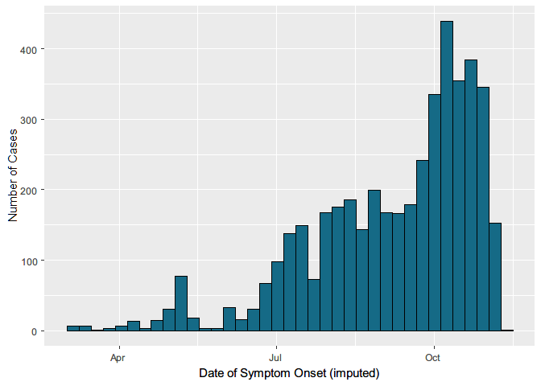

```r
ggplot(linelist, aes(x = DateOnset_imputed)) +      # Call data
       # Indicate visualization is histogram with bin width 7 days, custom colors
       geom_histogram(binwidth = 7, fill = "#156A86", color = "black") +
       # Renaming x and y axis labels
       xlab("Date of Symptom Onset (imputed)") + ylab("Number of Cases")
```

Based on the epidemic curve, it seems like a reasonable starting point for the time period of the analysis is two weeks before the start of July (say, June 15, which is a Monday), and a reasonable end point is the last week of October (say, November 1, which is a Sunday)

We then restrict our analyses to these dates into a new data file called `incidencetable_subset`

```r
incidencetable_subset <- incidencetable %>%
  filter(DateOnset_imputed >= as.Date("2020-06-15") & DateOnset_imputed <= as.Date("2020-11-01"))
# %>% is a pipe filter in the dplyr package that makes coding more readable
# Replace the dates according to your epidemic curve
```

## 3.3 Plotting reproduction number curve

And finally, we are ready to calculate the reproduction number. We will store the results in an object called `Rt`.

Note that the `R0` package has multiple methods available, but for this guide, we will use the [Wallinga and Teunis (2004) method](https://academic.oup.com/aje/article/160/6/509/79472).

Note that depending on the computational capacity of your computer, this takes some time. Be patient.

```r
Rt <- estimate.R(epid = incidencetable_subset$Count, t = incidencetable_subset$Date,
                 GT=mGT, method="TD", begin="2020-06-15", end="2020-11-01")
# epid declares the incidence counts
# t declares the corresponding dates
# GT declares the serial interval distribution curve generated earlier
# TD indicates the Wallinga and Teunis (2004) method
```

Save the `Rt` values per day together with the 95% confidence interval based on the values from `Rt` in a data frame called `Rt_table`.

```r
# Retrieve relevant results and generate a data frame
Rt_table <- data.frame(Rt$t, Rt$estimates$TD$R,
                       Rt$estimates$TD$conf.int$lower, Rt$estimates$TD$conf.int$upper)
# Note that you replace TD with the method you ended up using from R0.
# Use the command str(Rt) to identify what values you exactly need
# Assign column names
colnames(Rt_table) <- c("date", "Rt", "lowerCI", "upperCI")
# Remove last row since that is zero (it messes up the graph)
Rt_table <- slice(Rt_table, 1:(n()-1))
# Save as Excel file if you need it elsewhere (optional)
write_xlsx(Rt_table, "Rt_table.xlsx")
```

You may also plot the reproduction number curve. By default you can just use the command `plot(Rt)` but if you want to add some color, use `ggplot` instead and store the graph in an object called `rt_plot`

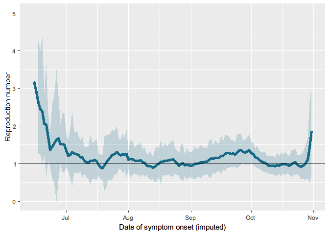

```r
rt_plot <- ggplot(Rt_table, aes(x = date, y = Rt)) + geom_line(color="#156A86", lwd = 2) +
    # Plot the line with point estimates, custom colors
                  geom_ribbon(aes(ymax = upperCI, ymin = lowerCI), fill="#156A86", alpha = 0.2) +
    # Plot the 95% confidence intervals, custom colors
                  xlab("Date of symptom onset (imputed)") + ylab("Reproduction number") +
    # Renaming x and y axis labels
                  geom_hline(yintercept = 1) +
    # Add a horizontal line indicating Rt = 1
                  ylim(c(0,5))
    # Limit the scale of the y-axis
rt_plot
```

The graph has the point estimates as solid lines and the 95% confidence intervals (CI) as bands surrounding the solid lines. There is also a horizontal line indicating Rt = 1, and the scale of the y-axis has been limited from 0 to 5.

This guide will not teach you how to interpret this curve, but note the following considerations:

- Interventions that attempted to break chains of transmission
- Geographic spread of the outbreak over time
- Precision of the estimates

If you want to export the graph for use outside of R, run the following code

```r
ggsave(file="rt_plot.png", rt_plot, width = 160, height = 90, unit = "mm")
# You may customize dimensions as you wish
```

## 3.4 Conducting subanalyses

Let’s say you want to limit or stratify the analysis by a certain variable. Using the dummy data, let us try to limit the analysis to Municipality C.

All you have to do is to filter the data first, then repeat the steps above on identifying an appropriate time period for analysis and running the calculations.

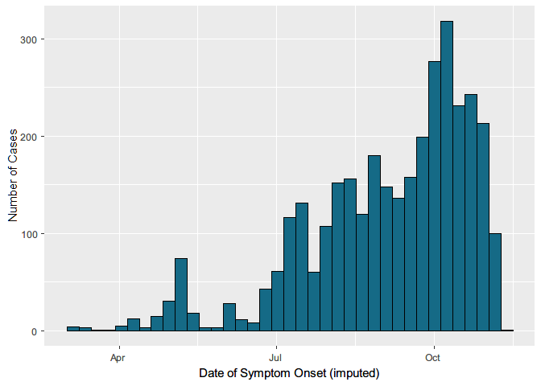

```r
# Filter all cases from Municipality C
linelist_C <- linelist %>% filter(Municipality == "Municipality C")
ggplot(linelist_C, aes(x = DateOnset_imputed)) +                  # Call data
       # Indicate visualizaiton is histogram with bin width 7 days, custom colors
       geom_histogram(binwidth = 7, fill = "#156A86", color = "black") +
       # Renaming x and y axis labels
       xlab("Date of Symptom Onset (imputed)") + ylab("Number of Cases")
```

As an alternative way of doing things above, you may subset the linelist first then generate the incidence table

```r
# Filter linelist by chosen dates
linelist_C_subset <-
  linelist_C %>% filter(DateOnset_imputed >= as.Date("2020-06-15") &
                          DateOnset_imputed <= as.Date("2020-10-25"))
# Generate incidence table as incidence object (incidence_C)
incidence_C <- incidence(linelist_C_subset$DateOnset_imputed)
# Generate incidence table as frequency table
incidencetable_C <- data.frame(incidence_C$dates, incidence_C$counts)
# Rename columns
colnames(incidencetable_C) <- c("DateOnset_imputed", "Count")
# Displaying the first six rows of incidence table
head(incidencetable_C)
```

```
##   DateOnset_imputed Count
## 1        2020-06-15     1
## 2        2020-06-16     1
## 3        2020-06-17     1
## 4        2020-06-18     0
## 5        2020-06-19     0
## 6        2020-06-20     3
```

```r
# Export incidence table to CSV if you need it elsewhere (optional)
write_xlsx(incidencetable_C, "incidencetable_C.xlsx")
```

Using the same serial interval distribution and method of estimation, you may calculate the reproduction numbers.

```r
Rt_C <- estimate.R(epid = incidencetable_C$Count, t = incidencetable_C$Date,
                   GT=mGT, method="TD", begin="2020-06-15", end="2020-10-25")
```

```r
Rt_C_table <- data.frame(Rt_C$t, Rt_C$estimates$TD$R,
                         Rt_C$estimates$TD$conf.int$lower, Rt_C$estimates$TD$conf.int$upper)
# Note that you replace TD with the method you ended up using from R0.
# Use the command str(Rt) to identify what values you exactly need
# Assign column names
colnames(Rt_C_table) <- c("date", "Rt", "lowerCI", "upperCI")
# Remove last row since that is zero (it messes up the graph)
Rt_C_table <- slice(Rt_table, 1:(n()-1))
# Save as Excel file if you need it elsewhere (optional)
write_xlsx(Rt_C_table, "Rt_C_table.xlsx")
```

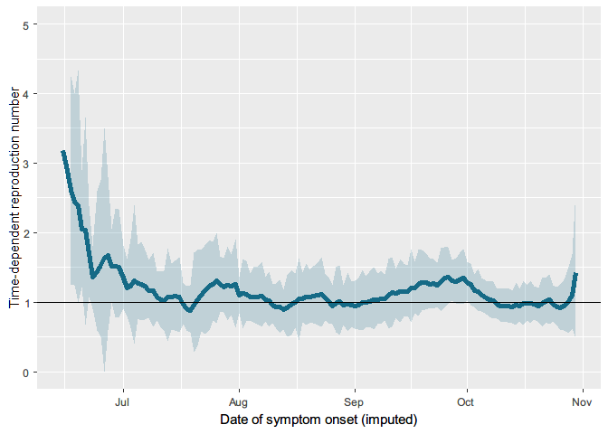

```r
rt_C_plot <-
  ggplot(Rt_C_table, aes(x = date, y = Rt)) + geom_line(color="#156A86", lwd = 2) +
         geom_ribbon(aes(ymax = upperCI, ymin = lowerCI), fill="#156A86", alpha = 0.2) +
         xlab("Date of symptom onset (imputed)") + ylab("Time-dependent reproduction number") +
         geom_hline(yintercept = 1) + ylim(c(0,5))
rt_C_plot
```

```r
ggsave(file="rt_plot_C.png", rt_C_plot, width = 160, height = 90, unit = "mm")
```

If there are any questions or comments, please feel free to drop a message over at Twitter - [`@`jasonhaw](https://www.twitter.com/jasonhaw_).